# Summative Assessment Section B

Keli Niu (ad21083)

2024-11-05

# B.1 Probability Density Function Analysis

Analyse a given probability density function (PDF) of a random variable. Its variable represents the time it takes for a product to return to the shelves after it has been sold out at a supermarket.

The probability density function is given by:

$$p_\lambda(x) = \begin{cases}
a e^{-\lambda (x - b)}, & x \ge b, \\
0, & x < b
\end{cases}$$

where $b > 0$ is a known constant, $\lambda > 0$ is a parameter of the distribution, and $a$ is to be determined by $\lambda$ and $b$.

## (1) Determining the Value of $a$

Since $p_\lambda(x)$ is a probability density function, it must satisfy two key properties: $p_\lambda(x) \geq 0$ for all $x$, and the total area under the PDF must be equal to 1. Therefore, we begin by ensuring that:

$$\int_{-\infty}^{\infty} p_\lambda(x)\, dx = 1$$

Since $p_\lambda(x) = 0$ for $x < b$, we only need to integrate from $b$ to $\infty$:

$$\int_b^{\infty} a e^{-\lambda (x - b)}\, dx = 1$$

To solve for $a$, we evaluate the integral:

$$\begin{aligned}
\int_b^{\infty} a e^{-\lambda (x - b)}\, dx
&= a \int_b^{\infty} e^{-\lambda (x - b)}\, dx \\
&= a \cdot \left[ -\frac{1}{\lambda} e^{-\lambda (x - b)}
\right]_{x=b}^{x=\infty} \\
&= 0-(-\frac{1}{\lambda}\cdot a) \\
&= \frac{a}{\lambda} = 1
\end{aligned}$$

Thus, we find that:

$$a = \lambda$$
Now, we verify that $p_\lambda(x) > 0$ for all $x \ge b$ when $a = \lambda$. Since $\lambda > 0$, it follows that

$$p_\lambda(x) = \lambda e^{-\lambda (x - b)} > 0, \quad \text{for } x
\ge b.$$
**Thus, the PDF is non-negative across its domain, confirming that $\boldsymbol{a = \lambda}$ is a valid choice.**

## (2) Population Mean and Standard Deviation

From the problem statement, we know that $X$ is a continuous random variable, and the population mean is equivalent to the expected value of $X$. The expected value $\mathbb{E}(X)$ is given by:

$$\mathbb{E}(X) = \int_{-\infty}^{\infty} x \, p_\lambda(x) \, dx$$
Since $p_\lambda(x) = 0$ for $x < b$, we only need to integrate from $b$ to $\infty$:

$$\begin{aligned}
\mathbb{E}(X)
&=\int_b^{\infty} x \, p_\lambda(x) \, dx \\
&= \int_b^{\infty} x \lambda e^{-\lambda (x - b)}\, dx \\
&= e^{\lambda b} \int_b^{\infty} x \lambda e^{-\lambda x}\, dx
\\
&= e^{\lambda b} (\left[ -x e^{-\lambda x} \right]_b^\infty +
\int_b^\infty e^{-\lambda x}\, dx) \\
&= e^{\lambda b} (0-(-b e^{-\lambda b})+(\left[
-\frac{1}{\lambda} e^{-\lambda x} \right]_b^\infty)) \\
&= e^{\lambda b} (b+\frac{1}{\lambda}) e^{-\lambda b} \\
&= b+\frac{1}{\lambda}
\end{aligned}$$

where in the 4th equality we have used integration by parts: let $u={\lambda} x$, $dv=e^{-\lambda x}dx$, which gives $du={\lambda}dx$ and $v=-\frac{1}{\lambda}e^{-\lambda x}$. Then using the integration by parts formula: $\int udv = uv - \int vdu$

To compute the variance $\operatorname{Var}(X)$, with integration by parts again we have
$$\begin{aligned}
\mathbb{E}(X^2)
&=\int_{-\infty}^{\infty} x^2 \, p_\lambda(x) \, dx \\
&=\int_b^{\infty} x^2 \lambda e^{-\lambda (x - b)}\, dx \\
&=e^{\lambda b} \int_b^{\infty} x^2 \lambda e^{-\lambda x}\, dx
\\
&=e^{\lambda b} (\left[ -x^2 e^{-\lambda x} \right]_b^\infty +
2 \int_b^\infty x e^{-\lambda x}\, dx) \\
&=e^{\lambda b} (0-(-b^2 e^{-\lambda b})+(\frac{2 e^{-\lambda
b}}{\lambda} \mathbb{E}(X))) \\
&=e^{\lambda b} ((b^2 e^{-\lambda b})+ \frac{2}{\lambda}
(b+\frac{1}{\lambda}) e^{-\lambda b}) \\
&=b^2+\frac{2 b}{\lambda}+\frac{2}{\lambda^2}
\end{aligned}$$

where in the 4th equality we have also used integration by parts.

Now, we can get the variance: $\text{Var}(X)=\mathbb{E}(X^2)-(\mathbb{E}(X))^2=b^2+\frac{2 b}{\lambda}+\frac{2}{\lambda^2}-(b+\frac{1}{\lambda})^2=\frac{1}{\lambda^2}$

So, the standard deviation $\sigma_X$ is the square root of the variance:
$$\sigma_X = \sqrt{\text{Var}(X)} = \sqrt{\frac{1}{\lambda^2}} =
\frac{1}{\lambda}.$$
**In summary, the population mean and standard deviation are $\mathbb{E}(X)= b+\frac{1}{\lambda}$ and $\sigma_X= \frac{1}{\lambda}$.**

## (3) Cumulative Distribution Function and the Quantile Function

#### The Cumulative Distribution Function:

The CDF $F_X(x)$ is defined as the probability that $X \leq x$:
$$F_X(x) = P(X \leq x) = \int_{-\infty}^{x} p_{\lambda}(t) \, dt$$
We consider two cases: 1. Since $F_X(x)=0$ for $x<b$:
$$F_X(x) = 0$$
2. Since $F_X(x)=p_{\lambda}(t)$ for $x\geq b$, we have:

$$\begin{aligned}
F_X(x)
&= \int_{b}^{x} p_{\lambda}(t) \, dt \\
&=\int_b^x \lambda e^{-\lambda (t - b)}\, dt \\
&=e^{\lambda b} \int_b^x \lambda e^{-\lambda t}\, dt \\
&=e^{\lambda b} \left[ -e^{-\lambda t} \right]_b^x \\
&=1-e^{-\lambda (x-b)}
\end{aligned}$$

#### The Quantile Function:

The quantile function $F_X^{-1} : [0, 1] \rightarrow \mathbb{R}$ is defined by:

$F_X^{-1}(p) := \inf \{ x \in \mathbb{R} : F_X(x) = \mathbb{P}(X \leq x) \geq p \} \ \text{for} \ p \in [0, 1]$.

The quantile function is the inverse of the CDF, so we starting from the equation $F_X(x) = 1 - e^{-\lambda (x-b)} = p$, solve for $x$:

$$e^{-\lambda (x-b)} = 1 - p$$

Taking the natural logarithm on both sides:

$$-\lambda (x-b) = \ln(1 - p)$$

Thus, the quantile function is:

$$F_X^{-1}(p) = b - \frac{\ln(1 - p)}{\lambda}$$
for $0 < p < 1$, $F_X^{-1}(p) = b$ for $p = 0$ and $F_X^{-1}(p) = +\infty$ for $p = 1$.

## (4) Maximum Likelihood Estimate

The likelihood function $L(\lambda)$ for $n$ independent observations is given by the product of their PDFs:

$$L(\lambda) = \prod_{i=1}^n p_\lambda(X_i)=\prod_{i=1}^n \lambda
e^{-\lambda (X_i - b)} = \lambda^n e^{-\lambda \sum_{i=1}^n (X_i - b)}$$
The log-likelihood function is obtained by taking the natural logarithm of the likelihood function to find the maximum likelihood estimate:
$$logL(\lambda)=nlog(\lambda)-\lambda\sum_{i=1}^n (X_i - b)$$
$$\frac{d}{d\lambda}logL(\lambda) = \frac{n}{\lambda} - \sum_{i=1}^n (X_i
- b)$$
We find:

If $\lambda<\frac{n}{\sum_{i=1}^n (X_i - b)}$, then $\frac{d}{d\lambda}logL(\lambda)>0$;

If $\lambda>\frac{n}{\sum_{i=1}^n (X_i - b)}$, then $\frac{d}{d\lambda}logL(\lambda)<0$.

**So the maximum likelihood estimate for $\lambda$ is $\hat{\lambda}_{\text{MLE}} =\frac{n}{\sum_{i=1}^n (X_i - b)}=\frac{1}{\overline{X}-b}$,** where ${\overline{X}}=\frac{1}{n}\sum_{i=1}^n X_i$.

## (5) Calculate the MLE of the parameter $\lambda$.

#### Step 1: Load the data and set the parameters

```r
#Load the library and read the file
library(tidyverse)
supermarket_data <- read_csv("supermarket_data_2024.csv")
#Set the parameters
b<-300
n<-nrow(supermarket_data)
```

#### Step 2: Calculate the MLE and display it

```r
#Calculate the MLE using the function in question (4)
lambda_MLE <- 1/(mean(supermarket_data$TimeLength, na.rm=TRUE)-b)
lambda_MLE
```

```
## [1] 0.01988426
```

#### Step 1: Set Up Parameters and Initialize Storage

```r
num_resamples <- 10000
# Create a numerical vector to store the results of the MLE
bootstrap_estimates <- numeric(num_resamples)
```

#### Step 2: Perform Bootstrap Resampling and Compute MLE for Each Resample

```r
# Set a random seed to ensure the results can be reproduced
set.seed(0)
for (i in 1:num_resamples) {
  #Samples are randomly selected from the original data
  sample_data <- sample(supermarket_data$TimeLength, size = length(supermarket_data$TimeLength), replace = TRUE)

  # Calculate the lambda MLE of the current resampling sample
  lambda_hat <- 1 / (mean(sample_data, na.rm = TRUE) - b)

  # Store the results of the MLE
  bootstrap_estimates[i] <- lambda_hat
}
```

#### Step 3: Calculate the 95% Confidence Interval for Lambda

```r
# Calculate 95% confidence intervals
Confidence_lower <- quantile(bootstrap_estimates, 0.025)
Confidence_upper <- quantile(bootstrap_estimates, 0.975)
Confidence <- c(Confidence_lower, Confidence_upper)

# Print the result
cat("Lambda MLE (original data):", 1 / (mean(supermarket_data$TimeLength, na.rm = TRUE) - b), "\n")
```

```
## Lambda MLE (original data): 0.01988426
```

```r
cat("95% Bootstrap Confidence Interval for Lambda:", Confidence, "\n")
```

```
## 95% Bootstrap Confidence Interval for Lambda: 0.01911276 0.02069813
```

#### Explanation

- `quantile()` is used to construct confidence intervals based on the results of Bootstrap resampling. Specifically, it determines the upper and lower limits of the parameter estimates at the 95% confidence level by calculating the 2.5% and 97.5% quantiles.

## (7) Display a plot of the mean square error of $λ_MLE$

#### Step 1: Set parameters

```r
library(tidyverse)
set.seed(0)
# Set parameters
lambda_true <- 2
b <- 0.01
num_trials_per_sample_size <- 100
sample_sizes <- seq(100, 5000, by = 10)
```

#### Step 2: Create Data Frame

```r
# Create data boxes with different sample sizes and trial times
df <- crossing(
  sample_size = sample_sizes,
  trial = 1:num_trials_per_sample_size) %>%
  # create samples
  mutate(samples = map(sample_size, ~ rexp(.x, rate = lambda_true) + b)) %>%
  # compute MLE
  mutate(lambda_mle = map_dbl(samples, ~ 1 / (mean(.x) - b)))
```

#### Step 3: Calculate Mean Squared Error (MSE) for Each Sample Size

```r
# Calculate the MSE for each sample size
df_mse <- df %>%
  group_by(sample_size) %>%
  summarise(mse = mean((lambda_mle - lambda_true)^2))
```

#### Step 4: Display a plot

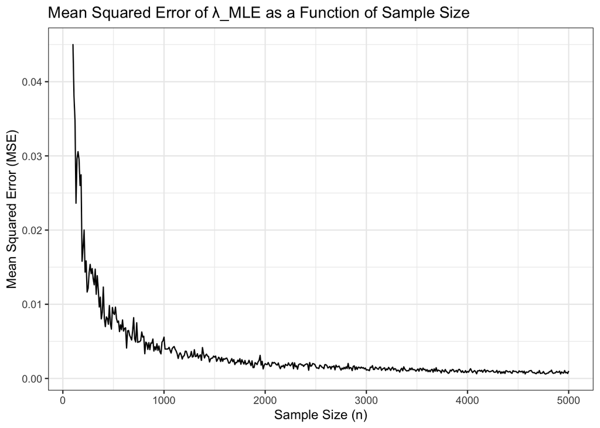

```r
# Show the plot
ggplot(data = df_mse, aes(x = sample_size, y = mse)) +
  geom_line() +
  theme_bw() +
  xlab("Sample Size (n)") +
  ylab("Mean Squared Error (MSE)") +
  ggtitle("Mean Squared Error of λ_MLE as a Function of Sample Size")
```

#### Explanation

- `crossing()` function creates a data box df that contains all the sample sizes combined with the number of trials.
- `map()` generates a set of random sample samples for each sample size.
- `rexp(.x, rate = lambda_true)` generates the sample of exponential distribution, and + b offsets the sample.
- `group_by(sample size)` : Groups data by sample size.
- Note: Note: Although `crossing()` and `map()` make the code simpler, they may reduce randomness in small samples, leading to smoother MSE results and may not capture the variability as effectively as independently generated samples in a simple loop.

# B.2 Ball Sampling Problem

## (1) The Probability Mass Function

First, from the problem, we know that the random variable $X$ represents the difference between the number of red balls drawn and the number of blue balls drawn. Therefore, $X$ has three possible values: 1. If we draw two red balls, then $X = 2$. 2. If we draw one red ball and one blue ball, then $X = 0$. 3. If we draw two blue balls, then $X = -2$.

Thus, the goal is to find the probability mass function (PMF) of the random variable $X$, that is, $p_X(x) = P(X = x)$ for $x \in \{2, 0, -2\}$.

#### Calculating the probabilities for each case

**1. Case 1: $X = 2$**
$$P(X = 2) =\frac{\binom{a}{2} \binom{b}{0}}{\binom{a+b}{2}} = \frac{a(a -
1)}{(a + b)(a + b - 1)}$$

**2. Case 2: $X = 0$**
$$P(X = 0) =\frac{\binom{a}{1} \binom{b}{1}}{\binom{a+b}{2}} \frac{2ab}{(a
+ b)(a + b - 1)}$$

**3. Case 3: $X = -2$**
$$P(X = -2) = \frac{\binom{a}{0} \binom{b}{2}}{\binom{a+b}{2}}=\frac{b(b -
1)}{(a + b)(a + b - 1)}$$

#### Therefore, the PMF is:

$$p_X(x) = \begin{cases}
\frac{a(a - 1)}{(a + b)(a + b - 1)}, & \text{if } x = 2 \\
\frac{2ab}{(a + b)(a + b - 1)}, & \text{if } x = 0 \\
\frac{b(b - 1)}{(a + b)(a + b - 1)}, & \text{if } x = -2
\end{cases}$$

## (2) The Expression of the Expectation

The expectation $\mathbb{E}(X)$ is defined as the sum of each possible value of the random variable multiplied by its corresponding probability.

So, we have:

$$\begin{aligned}
\mathbb{E}(X)
&= \sum_{x} x \cdot p_X(x) \\
&=2 \cdot \frac{a(a - 1)}{(a + b)(a + b - 1)} + 0 \cdot
\frac{2ab}{(a + b)(a + b - 1)} + (-2) \cdot \frac{b(b - 1)}{(a + b)(a +
b - 1)} \\
&= \frac{2(a(a - 1) - b(b - 1))}{(a + b)(a + b - 1)}
\end{aligned}$$

## (3) The Expression of the Variance

We can use the formula, and have:

$$\begin{aligned}
\operatorname{Var}(X)
&=\mathbb{E}(X^2)-(\mathbb{E}(X))^2 \\
&=(2^2 \cdot \frac{a(a - 1)}{(a + b)(a + b - 1)} + 0^2 \cdot
\frac{2ab}{(a + b)(a + b - 1)} + (-2)^2 \cdot \frac{b(b - 1)}{(a + b)(a
+ b - 1)})-\left( \frac{2(a(a - 1) - b(b - 1))}{(a + b)(a + b - 1)}
\right)^2 \\
&= \frac{4(a(a - 1) + b(b - 1))}{(a + b)(a + b - 1)} - \frac{4(a(a -
1) - b(b - 1))^2}{(a + b)^2 (a + b - 1)^2}
\end{aligned}$$

## (4) Use R to Represent the Expectation and the Variance

```r
# Step 1: Function to compute the expectation E(X)
compute_expectation_X <- function(a, b) {
  # Calculating E(X) using the formula derived previously
  expectation_X <- (2 * (a * (a - 1) - b * (b - 1))) / ((a + b) * (a + b - 1))
  return(expectation_X)
}

# Step 2: Function to compute the variance Var(X)
compute_variance_X <- function(a, b) {
  # Calculating E(X^2) based on the possible values of X
  E_X_squared <- (4 * (a * (a - 1) + b * (b - 1))) / ((a + b) * (a + b - 1))

  E_X <- compute_expectation_X(a, b)

  # Calculating Var(X) = E(X^2) - (E(X))^2
  variance_X <- E_X_squared - E_X^2
  return(variance_X)
}
```

## (5) The Expectation of the Random Variable $\overline{X}$

By the linearity of expectation, we can find the expectation of the sample mean $\mathbb{E}(\overline{X})$ as follows:
$$\begin{aligned}
\mathbb{E}(\overline{X})
&=\mathbb{E}\left(\frac{1}{n} \sum_{i=1}^n X_i\right)\\
&=\frac{1}{n} \sum_{i=1}^n \mathbb{E}(X_i)\\
&=\frac{1}{n} \cdot n \cdot \mathbb{E}(X) \\
&= \mathbb{E}(X) \\
&= \frac{2(a(a - 1) - b(b - 1))}{(a + b)(a + b - 1)}
\end{aligned}$$

where in the third equality, we have used the fact that $X_1, X_2, \dots, X_n$ are $i.i.d.$ random variables, meaning $E(X_i) = E(X)$ for each $i$.

## (6) The Variance of the Random Variable $\overline{X}$

For the sample mean $\overline{X}$ of $i.i.d.$ random variables, we can derive the following formula step by step according to the nature of variance:

$$\begin{aligned}
\operatorname{Var}(\overline{X})
&= \operatorname{Var} \left( \frac{1}{n} \sum_{i=1}^n X_i \right) \\
&= \frac{1}{n^2} \operatorname{Var} \left( \sum_{i=1}^n X_i \right)
\\
&= \frac{1}{n^2} \sum_{i=1}^n \operatorname{Var}(X_i) \\
&= \frac{1}{n^2} \cdot n \cdot \operatorname{Var}(X) \\
&= \frac{\operatorname{Var}(X)}{n} \\
&= \frac{1}{n} (\frac{4(a(a - 1) + b(b - 1))}{(a + b)(a + b - 1)} -
\frac{4(a(a - 1) - b(b - 1))^2}{(a + b)^2 (a + b - 1)^2})
\end{aligned}$$

## (7) Generate $i.i.d.$ Sample of $X$

```r
# Function to generate a sample of independent copies of X
sample_Xs <- function(a, b, n) {
  # Define the possible values of X
  values <- c(2, 0, -2)

  # Calculate the probabilities
  p_X_2 <- a * (a - 1) / ((a + b) * (a + b - 1))
  p_X_0 <- 2 * a * b / ((a + b) * (a + b - 1))
  p_X_minus2 <- b * (b - 1) / ((a + b) * (a + b - 1))

  # Generate n samples of X based on the probabilities
  samples <- sample(values, size = n, replace = TRUE, prob = c(p_X_2, p_X_0, p_X_minus2))

  return(samples)
}
```

## (8) Validation derivation

#### Step 1: Compute theoretical expectation and variance

```r
# Set parameters
a <- 3
b <- 5
n <- 100000

theoretical_expectation <- compute_expectation_X(a, b)
theoretical_variance <- compute_variance_X(a, b)
cat("Theoretical Expectation E(X):", theoretical_expectation, "\n")
```

```
## Theoretical Expectation E(X): -0.5
```

```r
cat("Theoretical Variance Var(X):", theoretical_variance, "\n")
```

```
## Theoretical Variance Var(X): 1.607143
```

#### Step 2: Generate a sample and compute sample mean and variance

```r
set.seed(0)
samples_X <- sample_Xs(a, b, n)
samples_mean <- mean(samples_X)
samples_variance <- var(samples_X)
cat("Sample Mean:", samples_mean, "\n")
```

```
## Sample Mean: -0.50252
```

```r
cat("Sample Variance:", samples_variance, "\n")
```

```
## Sample Variance: 1.60765
```

#### Step 3: Compare results

```r
different_mean<-samples_mean - theoretical_expectation
different_variance<-samples_variance - theoretical_variance
cat("Difference between Sample Mean and Theoretical E(X):",different_mean , "\n")
```

```
## Difference between Sample Mean and Theoretical E(X): -0.00252
```

```r
cat("Difference between Sample Variance and Theoretical Var(X):",different_variance, "\n")
```

```
## Difference between Sample Variance and Theoretical Var(X): 0.000506869
```

*Expectation*

*Variance*

## (9) Conduct a Simulation study with 50000 Trials

```r
a <- 3
b <- 5
n <- 100
trials <- 50000

# Store sample means
sample_means <- numeric(trials)
set.seed(6)
for (i in 1:trials) {
  sample_data <- sample_Xs(a, b, n)
  # Calculate the mean of every trial
  sample_means[i] <- mean(sample_data)
}
```

## (10) Plot a Comparison

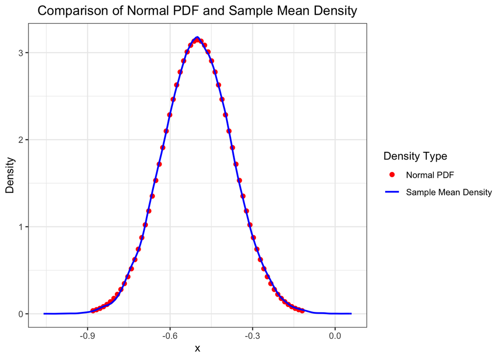

```r
# Using the function to calculate the expectation and standard deviation
mu<-compute_expectation_X(a,b)
sigma <- sqrt(compute_variance_X(a, b) / n)

# Set the range of xi
xi <- seq(mu - 3 * sigma, mu + 3 * sigma, by = 0.1 * sigma)
# Calculate the probability density fµ,σ(xi) for each xi
f_mu_sigma <- dnorm(xi, mean = mu, sd = sigma)

ggplot() +
  # Scatter plot for the normal PDF points
  geom_point(data = data.frame(x = xi, y = f_mu_sigma), aes(x = x, y = y,color = "Normal PDF"), size=1.8) +
  # Kernel density line for the sample means
  geom_line(stat = "density", data = data.frame(x = sample_means), aes(x = x,color = "Sample Mean Density"),size=0.8) +

  labs(x = "x", y = "Density", title = "Comparison of Normal PDF and Sample Mean Density")  +
  theme_bw()+
  theme(plot.title = element_text(hjust = 0.5))+
  scale_color_manual(name = "Density Type", values = c("Normal PDF" ="red" ,"Sample Mean Density" ="blue"))
```

## (11) Describe and Explain the Relationship

#### Description the Relationship

In the plot, we observe that the kernel density estimation of the sample mean (blue curve) closely aligns with the theoretical normal distribution $f_{\mu, \sigma}$ (red points). This phenomenon can be explained by the *Central Limit Theorem (CLT)*.

#### Explanation

*Description and explanation of the central limit theorem*

The Central Limit Theorem describes the behavior of the sample mean distribution when the sample size is sufficiently large. Specifically, consider a set of independent and identically distributed ($i.i.d.$) random variables $X_1, X_2, \dots, X_n$, each with expected value $\mu$ and variance $\sigma^2$. When the sample size $n$ is large enough, the distribution of the sample mean $\overline{X}$ approximates a normal distribution with mean $\mu$ and variance $\frac{\sigma^2}{n}$.

This means that, as long as $n$ is sufficiently large, the sample mean distribution will approximate a normal distribution.

The Central Limit Theorem can be expressed as:

$$\lim_{n \to \infty} \mathbb{P} \left( \sqrt{\frac{n}{\sigma^2}} \left(
\frac{1}{n} \sum_{i=1}^n X_i - \mu \right) \leq x \right) = \mathbb{P}(Z
\leq x),$$

*Combined with the theorem to explain this problem*

In the context of this question, we selected a sample size of $n = 100$ and conducted 50,000 trials. In each trial, we generated a sample mean $\bar{X}$, resulting in a total of 50,000 sample means. According to the Central Limit Theorem, because the sample size $n = 100$ is sufficiently large, the distribution of the sample means should approximate a normal distribution $N\left(\mu, \frac{\sigma^2}{n}\right)$.

Therefore, the close alignment between the kernel density of the sample means (blue curve) and the theoretical normal distribution $f_{\mu, \sigma}$ (red points) in the plot is a direct manifestation of the Central Limit Theorem.